# Storm events and the consequences across the United States.

# Synopsis

The aim of this report is to understand the type of storm events across the Untied States that are most  
harmful for the populations health and have the greatest economic consequences.  
Concretely research on the following questions will be conducted: - Across the United States, which types of events are most harmful with respect to population health? - Across the United States, which types of events have the greatest economic consequences?

# Data Processing

### Loading and processing the raw data

The data is uploaded form the course web site [Storm data](http://d396qusza40orc.cloudfront.net/repdata%2Fdata%2FStormData.csv.bz2)

Documentation describing the database is available at the following locations - National Wather service [Storm Data Documentation](https://d396qusza40orc.cloudfront.net/repdata%2Fpeer2_doc%2Fpd01016005curr.pdf) - National Climatic Data Center Storm Events [FAQ](https://d396qusza40orc.cloudfront.net/repdata%2Fpeer2_doc%2FNCDC%20Storm%20Events-FAQ%20Page.pdf)

```r
options(scipen = 1, digits = 2)
library(data.table)
library(dplyr)
```

### Reading the data

First download the data file

```r
download.file("http://d396qusza40orc.cloudfront.net/repdata%2Fdata%2FStormData.csv.bz2","repdata_data_StormData.csv.bz2")
```

Read the data from the bz2 commpressed file. The fields are delimited by a ,  
To avoid the long reading time of the file every time the block cache option is enabled.

The varables we goning to user regarinding the questions asked are : - EVTYPE : the event type (flood, tornado, etc) - FATALITIES:the number of fatalities per storm  
- INJURIEs : the number of injuries per storm  
- PROPDMG : the ammount of damage on properties  
- PROPDMGEXP: the magnitued of properties damage (thousands, millions) - CROPDMG : te ammount of damage on crops - CROPDMGEXP : the magnitued of crop damage (thousands, millions)

To make the data set more compact other variables are removed.

```r
stormdata <- data.table(read.table("repdata_data_StormData.csv.bz2",header = TRUE, sep = ",",na.strings = "")) %>%
             select(EVTYPE, FATALITIES, INJURIES, PROPDMG, PROPDMGEXP, CROPDMG,CROPDMGEXP)
```

After reading we test the first rows, there should be 902297 observations and 7 variables.

```r
dim(stormdata)
```

```
## [1] 902297      7
```

```r
str(stormdata)
```

```
## Classes 'data.table' and 'data.frame':   902297 obs. of  7 variables:
##  $ EVTYPE    : Factor w/ 985 levels "   HIGH SURF ADVISORY",..: 834 834 834 834 834 834 834 834 834 834 ...
##  $ FATALITIES: num  0 0 0 0 0 0 0 0 1 0 ...
##  $ INJURIES  : num  15 0 2 2 2 6 1 0 14 0 ...
##  $ PROPDMG   : num  25 2.5 25 2.5 2.5 2.5 2.5 2.5 25 25 ...
##  $ PROPDMGEXP: Factor w/ 18 levels "-","?","+","0",..: 16 16 16 16 16 16 16 16 16 16 ...
##  $ CROPDMG   : num  0 0 0 0 0 0 0 0 0 0 ...
##  $ CROPDMGEXP: Factor w/ 8 levels "?","0","2","B",..: NA NA NA NA NA NA NA NA NA NA ...
##  - attr(*, ".internal.selfref")=<externalptr>
```

#### Across the United States, which types of events are most harmful with respect to population health?

To determine the types of storms that are the most harmfull for the popiation, the data set is grouped by the types of storms as indicated in the EVTYPE variable and add the total ammount of direct and indirect fatalities and injuries. The twenty most harmfull events are show all other events are summarized to one others event type.

```r
most.harmfull <- stormdata %>%
                 group_by(EVTYPE) %>%
                 summarise_each(funs(sum), FATALITIES, INJURIES) %>%
                 arrange(desc(FATALITIES), desc(INJURIES))
total.events = dim(most.harmfull)[1]

less.harmfull <- most.harmfull[-c(1:20)]  %>%
                 ungroup() %>%
                 summarise_each(funs(sum), FATALITIES, INJURIES) %>%
                 mutate(EVTYPE = "Others")

most.harmfull <- rbind (most.harmfull[1:20], less.harmfull)
```

#### Across the United States, which types of events have the greatest economic consequences?

To calculate the events with the greatest economic consequences the total aamount of proteries damage and crops lost damages is added togeter by event type. Before the values can be added to getter the values have to be normalized. We normalize to millions of dollar.

```r
normalize.values <- function(value, exp) {
  ifelse(is.na(exp),  value / 1e6,
    ifelse ( (exp == "K"),  value / 1e3,
      ifelse ( (exp == "M"),  value ,
        ifelse ( (exp == "B"),  value * 1e3, value /1e6))))
 }

economic.consequences <- stormdata %>%
    mutate (PROPDMGEXP = as.character(PROPDMGEXP)) %>%
    mutate (CROPDMGEXP = as.character(CROPDMGEXP)) %>%
    mutate(damage.million.dollar = normalize.values(PROPDMG, PROPDMGEXP)+ normalize.values(CROPDMG,CROPDMGEXP)) %>%
    group_by(EVTYPE) %>%
    summarise_each(funs(sum),damage.million.dollar) %>%
    arrange(desc(damage.million.dollar))

less.economic.consequences <-economic.consequences[-c(1:20)]  %>%
                 ungroup() %>%
                 summarise_each(funs(sum),damage.million.dollar) %>%
                 mutate(EVTYPE = "Others")

economic.consequences <- rbind (economic.consequences[1:20],less.economic.consequences)
```

# Results

The twenty most harmfull events of the total of 985 events for the population is shown in the table below.

```r
most.harmfull
```

```
##                      EVTYPE FATALITIES INJURIES
##  1:                 TORNADO       5633    91346
##  2:          EXCESSIVE HEAT       1903     6525
##  3:             FLASH FLOOD        978     1777
##  4:                    HEAT        937     2100
##  5:               LIGHTNING        816     5230
##  6:               TSTM WIND        504     6957
##  7:                   FLOOD        470     6789
##  8:             RIP CURRENT        368      232
##  9:               HIGH WIND        248     1137
## 10:               AVALANCHE        224      170
## 11:            WINTER STORM        206     1321
## 12:            RIP CURRENTS        204      297
## 13:               HEAT WAVE        172      309
## 14:            EXTREME COLD        160      231
## 15:       THUNDERSTORM WIND        133     1488
## 16:              HEAVY SNOW        127     1021
## 17: EXTREME COLD/WIND CHILL        125       24
## 18:             STRONG WIND        103      280
## 19:                BLIZZARD        101      805
## 20:               HIGH SURF        101      152
## 21:                  Others       1632    12337
##                      EVTYPE FATALITIES INJURIES
```

The tables shows that the most harmfull events are TORNADO events.

The twenty most damaging events of the total of 985 are show in the bar plot below.

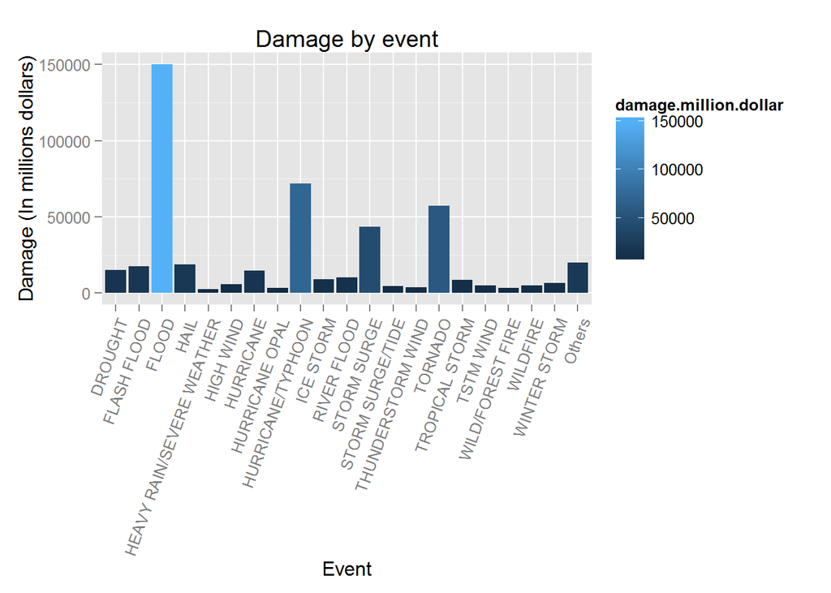

```r
library(ggplot2)
chart <- ggplot(aes(x=EVTYPE,y=damage.million.dollar, fill=damage.million.dollar), data = economic.consequences ) +
          geom_bar( stat="identity") +
          ggtitle("Damage by event") +
          ylab("Damage (In millions dollars)") +
          xlab("Event") +
          theme(axis.text.x=element_text(angle=70, hjust=1))
print(chart)
```

The figure shows that the most damaging events are FLOOD events.